# Explore quanTIseq results

Stephanie J. Spielman

2025-01-10

The goal of this notebook is to perform some visual exploration on `quanTIseq` results to assess cell type proportions across samples and projects. `quanTIseq` estimates the proportions of the following cell types (note they use these strings, not ontologies):

- `B.cells`
- `Macrophages.M1`
- `Macrophages.M2`
- `Monocytes`
- `Neutrophils`
- `NK.cells`
- `T.cells.CD4`
- `T.cells.CD8`
- `Tregs`
- `Dendritic.cells`
- `Other`
  - In our data, this *very putatively* represents tumor cells, means we can loosely think of this value as proportional to tumor purity.
  - However, since `quanTIseq` focuses on immune cell types and not other “normal” cell types that might be present (e.g. epithelial), this is not necessarily a rigorous or reliable assumption.

This notebook also assumes the ScPCA sample metadata is available in, relative to the repository root,`s3_files/scpca-sample-metadata.tsv`.

## Setup

```r
renv::load()

library(ggplot2)
theme_set(theme_bw())
```

### Functions

This chunk defines a helper function for making barplots throughout this notebook.

```r
#' Make a barplot using ggplot::geom_col()
#'
#' Variables should be provided plain without quotes.
#'
#' @param df Data frame to plot
#' @param xvar Variables to place on x-axis
#' @param yvar Variable to place on y-axis
#' @param facetvar Variable to use for faceting with facet_wrap()
#' @param fillvar Optional variable to use for fill
#' @param facet_rows Number of rows for facetting
#'
#' @returns ggplot object
make_barplot <- function(df, xvar, yvar, facetvar, fillvar = NULL, facet_rows = 1) {

  p <- ggplot(df) +
    aes(x = {{xvar}}, y = {{yvar}}) +
    geom_col() +
    facet_wrap(vars({{facetvar}}), scales = "free_x", nrow = facet_rows) +
    scale_y_continuous(expand = c(0,0)) +
    theme(axis.text.x = element_blank()) # will be overridden if we want the axis

  # use missing() instead of is.null() to avoid bug since this is a symbol
  if (!missing(fillvar)) {
    p <- p +
      aes(fill = {{fillvar}}) +
      # not CVD-friendly, but has enough colors which should be fine for exploration here
      scale_fill_brewer(palette = "Paired") +
      theme(legend.position = "bottom")
  }

  return(p)
}
```

### Paths

```r
results_dir <- here::here("analysis", "bulk-deconvolution", "results")
sample_metadata_file <- here::here("s3_files", "scpca-sample-metadata.tsv") # for diagnosis

quantiseq_files <- list.files(
  path = results_dir,
  full.names = TRUE,
  pattern = "*-quantiseq.tsv$"
)
project_ids <- stringr::str_split_i(basename(quantiseq_files), pattern = "-", i = 1)
quantiseq_files <- setNames(quantiseq_files, project_ids)
```

### Prepare input data

```r
# We want the diagnosis information for visualization
metadata <- readr::read_tsv(sample_metadata_file) |>
  dplyr::select(sample_id = scpca_sample_id, diagnosis)
```

```r
# Read in quanTIseq result TSVs and combine into single data frame
quantiseq_df <- quantiseq_files |>
  purrr::map(\(file) readr::read_tsv(file, show_col_types = FALSE)) |>
  purrr::list_rbind(names_to = "project_id") |>
  # include diagnosis information
  dplyr::left_join(metadata, by = "sample_id") |>
  # add indicator column if the celltype is "Other"
  dplyr::mutate(is_other = quantiseq_celltype == "Other")
head(quantiseq_df)
```

| project_id | sample_id | quantiseq_celltype | proportion | diagnosis | is_other |
| --- | --- | --- | --- | --- | --- |
| SCPCP000001 | SCPCS000001 | B.cells | 0.021196731 | Anaplastic glioma | FALSE |
| SCPCP000001 | SCPCS000001 | Macrophages.M1 | 0.000000000 | Anaplastic glioma | FALSE |
| SCPCP000001 | SCPCS000001 | Macrophages.M2 | 0.002662645 | Anaplastic glioma | FALSE |
| SCPCP000001 | SCPCS000001 | Monocytes | 0.113940420 | Anaplastic glioma | FALSE |
| SCPCP000001 | SCPCS000001 | Neutrophils | 0.000000000 | Anaplastic glioma | FALSE |
| SCPCP000001 | SCPCS000001 | NK.cells | 0.026224701 | Anaplastic glioma | FALSE |

```r
# tabulate total samples which will be later used to calculate proportions
total_samples <- length(unique(quantiseq_df$sample_id))
```

Let’s remind ourselves also of the diagnoses present here:

```r
quantiseq_df |>
  dplyr::group_by(project_id) |>
  dplyr::summarize(diagnoses = paste(unique(diagnosis), collapse = ", "))
```

| project_id | diagnoses |
| --- | --- |
| SCPCP000001 | Anaplastic glioma, Glioblastoma, High-grade glioma, Diffuse midline glioma, Anaplastic astrocytoma |
| SCPCP000002 | Pilocytic astrocytoma, Ganglioglioma, Low-grade glioma, Ganglioglioma/ATRT |
| SCPCP000006 | Wilms tumor |
| SCPCP000009 | Medulloblastoma, Ependymoma, Pilocytic astrocytoma, Dysplastic gangliocytoma, Primitive neuroectodermal tumor, Desmoplastic ganglioglioma, Anaplastic ganglioglioma, Dysembryoplastic neuroepithelial tu… |
| SCPCP000017 | Osteosarcoma |

Below is a table with high-level diagnoses for each ScPCA project:

| Project | High-level diagnosis |
| --- | --- |
| SCPCP000001 | High-grade glioma |
| SCPCP000002 | Low-grade glioma |
| SCPCP000006 | Wilms tumor |
| SCPCP000009 | CNS tumors |
| SCPCP000017 | Osteosarcoma |

For ease interpreting subsequent figures, we’ll add these high-level diagnoses into the data frame with a project number indicator (excluding leading 0s).

```r
quantiseq_df <- quantiseq_df |>
  dplyr::mutate(
    project_diagnosis = dplyr::case_match(
      project_id,
      "SCPCP000001" ~ "01: High-grade glioma",
      "SCPCP000002" ~ "02: Low-grade glioma",
      "SCPCP000006" ~ "06: Wilms tumor",
      "SCPCP000009" ~ "09: CNS tumors",
      "SCPCP000017" ~ "17: Osteosarcoma"
    ))
```

## Visualization

### What proportion of cells were classified?

First, let’s look at the overall distribution classified cells in each sample, i.e. the proportion of labeled cells as opposed to “Other” cells, which *theoretically* represent tumor cells in our samples.

We’ll make histogram showing the proportion of classified cells for samples in each project:

```r
classified_df <- quantiseq_df |>
  dplyr::filter(is_other) |>
  dplyr::mutate(classified_proportion = 1 - proportion)

sample_order <- classified_df |>
  dplyr::group_by(project_diagnosis) |>
  dplyr::arrange(classified_proportion) |>
  dplyr::pull(sample_id)
```

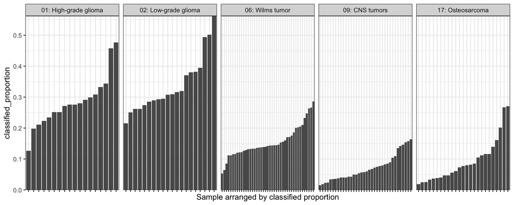

```r
make_barplot(
  classified_df,
  xvar = forcats::fct_relevel(sample_id, sample_order),
  yvar = classified_proportion,
  facetvar = project_diagnosis
) +
  xlab("Sample arranged by classified proportion")
```

The percentage of classified cells in each sample ranges from close to 0 to up to around 0.55. `SCPCP000001` and `SCPCP000002` tend to have the highest values.

Which samples have lower classified proportions?

```r
classified_df |>
  dplyr::filter(classified_proportion <= 0.05) |>
  dplyr::select(project_id, sample_id, classified_proportion, diagnosis) |>
  dplyr::arrange(classified_proportion)
```

| project_id | sample_id | classified_proportion | diagnosis |
| --- | --- | --- | --- |
| SCPCP000009 | SCPCS000145 | 0.01523119 | Primitive neuroectodermal tumor |
| SCPCP000017 | SCPCS000410 | 0.01842900 | Osteosarcoma |
| SCPCP000009 | SCPCS000166 | 0.01863491 | Schwannoma |
| SCPCP000009 | SCPCS000139 | 0.02278053 | Medulloblastoma |
| SCPCP000009 | SCPCS000140 | 0.02413174 | Desmoplastic ganglioglioma |
| SCPCP000017 | SCPCS000246 | 0.02485051 | Osteosarcoma |
| SCPCP000017 | SCPCS000611 | 0.02581268 | Osteosarcoma |
| SCPCP000017 | SCPCS000247 | 0.03291714 | Osteosarcoma |
| SCPCP000009 | SCPCS000131 | 0.03423350 | Pilocytic astrocytoma |
| SCPCP000009 | SCPCS000146 | 0.03539793 | Subependymoma |

[output cut: 14 more lines]

### Proportions of cell types

If we consider *only* cells which were classified, what proportions of cell types are represented across samples?

First, we’ll need to remove the “Other” cells and normalize the remaining values to sum to 1.

```r
classified_normalized_df <- quantiseq_df |>
  dplyr::filter(!is_other) |>
  dplyr::group_by(sample_id) |>
  # renormalize so non-other sums to 1
  dplyr::mutate(proportion = proportion / sum(proportion))
```

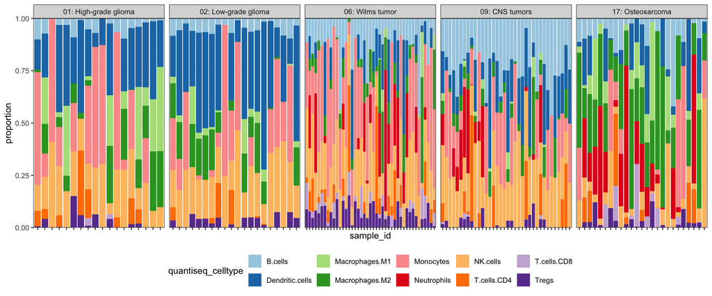

```r
make_barplot(
  classified_normalized_df,
  xvar = sample_id,
  yvar = proportion,
  fillvar = quantiseq_celltype,
  facetvar = project_diagnosis
)
```

Let’s look at some associated summaries for this sample-specific information.

Of the 10 cell types in `quanTIseq`, how many are represented in each sample? For this, we’ll make a histogram of the number of cell types identified per sample (regardless of their proportion).

```r
celltype_counts_df <- quantiseq_df |>
  dplyr::filter(!is_other) |>
  dplyr::group_by(project_diagnosis, sample_id) |>
  dplyr::summarize(num_celltypes = sum(proportion != 0))
```

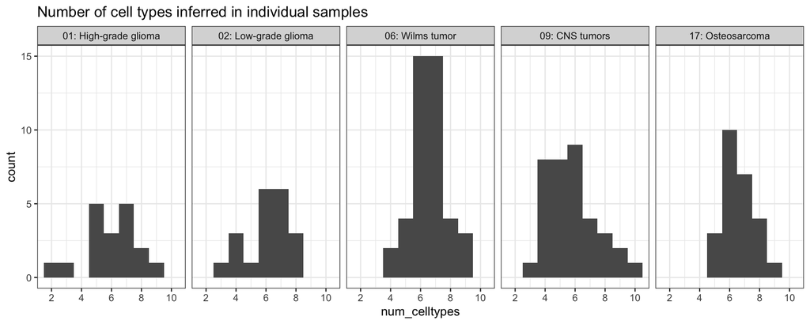

```r
ggplot(celltype_counts_df) +
  aes(x = num_celltypes) +
  geom_histogram(center = 0, binwidth = 1) +
  scale_x_continuous(breaks = scales::breaks_pretty()) +
  facet_wrap(vars(project_diagnosis), nrow = 1) +
  ggtitle("Number of cell types inferred in individual samples")
```

We can also make an associated summary table:

```r
celltype_counts_df |>
  dplyr::group_by(project_diagnosis) |>
  dplyr::summarize(
    min_celltypes = min(num_celltypes),
    median_celltypes = median(num_celltypes),
    max_celltypes = max(num_celltypes),
  )
```

| project_diagnosis | min_celltypes | median_celltypes | max_celltypes |
| --- | --- | --- | --- |
| 01: High-grade glioma | 2 | 6 | 9 |
| 02: Low-grade glioma | 3 | 6 | 8 |
| 06: Wilms tumor | 4 | 7 | 9 |
| 09: CNS tumors | 3 | 6 | 10 |
| 17: Osteosarcoma | 5 | 6 | 9 |

Overall, we see that only all samples have at least two cell types, and only one sample was inferred to contain all 10 cell types. On average, 6-7 cell types are represented per sample, which is more than 50%.

Next, in what proportion of samples is each cell type represented? Again, this only considers cell type presence and absence.

```r
# calculate number of celltypes per sample
samples_per_celltype_df <- quantiseq_df |>
  dplyr::filter(!is_other) |>
  dplyr::mutate(celltype_present = proportion > 0) |>
  dplyr::group_by(quantiseq_celltype, project_diagnosis) |>
  dplyr::summarize(n_samples = sum(celltype_present))
# convert number to proportion
samples_per_celltype_df <- quantiseq_df |>
  dplyr::filter(is_other) |>
  dplyr::count(project_diagnosis) |>
  dplyr::right_join(samples_per_celltype_df) |>
  dplyr::mutate(prop_samples = n_samples / n)
```

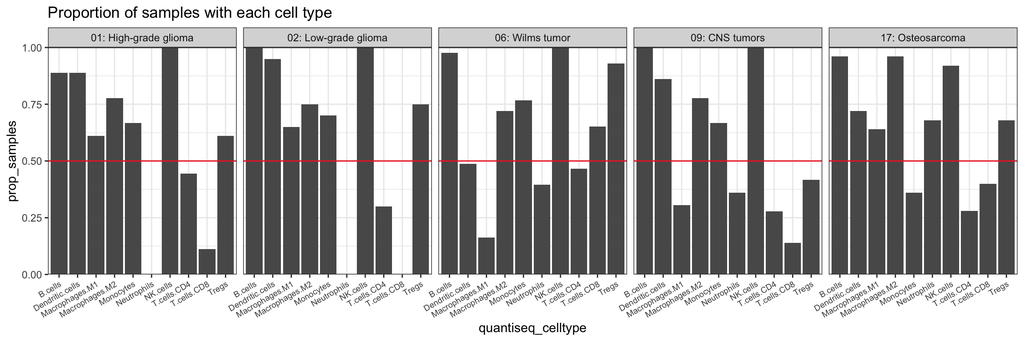

```r
make_barplot(
  samples_per_celltype_df,
  xvar = quantiseq_celltype,
  yvar = prop_samples,
  facetvar = project_diagnosis
) +
  # add guiding line at 0.5
  geom_hline(yintercept = 0.5, color = "firebrick2") +
  theme(axis.text.x = element_text(angle = 30, hjust = 1, size = rel(0.8))) +
  ggtitle("Proportion of samples with each cell type")
```

- This plot emphasizes that the following cell types are not present or more infrequently represented (<25%) across samples:
  - `SCPCP000001` has no `Neutrophils`, and few samples have `T.cells.CD8`
  - `SCPCP000002` has no `Neutrophils` or `T.cells.CD8`
  - Few samples in `SCPCP000006` have `Macrophages.M1`
  - Few samples in `SCPCP000009` have `T.cells.CD8`

## Tumor purity and cell types

This section assesses if there is a relationship between a sample’s tumor purity is correlated with the number of cell types identified. Again, we only have a *loose proxy* for tumor purity as the the proportion of cells with an “Other” cell type.

We do not expect a relationship here, since a relationship would indicate a bias that the overall content of a sample influences the algorithm’s ability to identify cell types in the first place.

```r
# Create a data frame with the porportion of other and the number of cell types
other_prop_df <- quantiseq_df |>
  dplyr::filter(is_other)

other_prop_df <- celltype_counts_df |>
  dplyr::ungroup() |>
  dplyr::left_join(other_prop_df) |>
  dplyr::select(project_id, sample_id, num_celltypes, other_proportion = proportion)
```

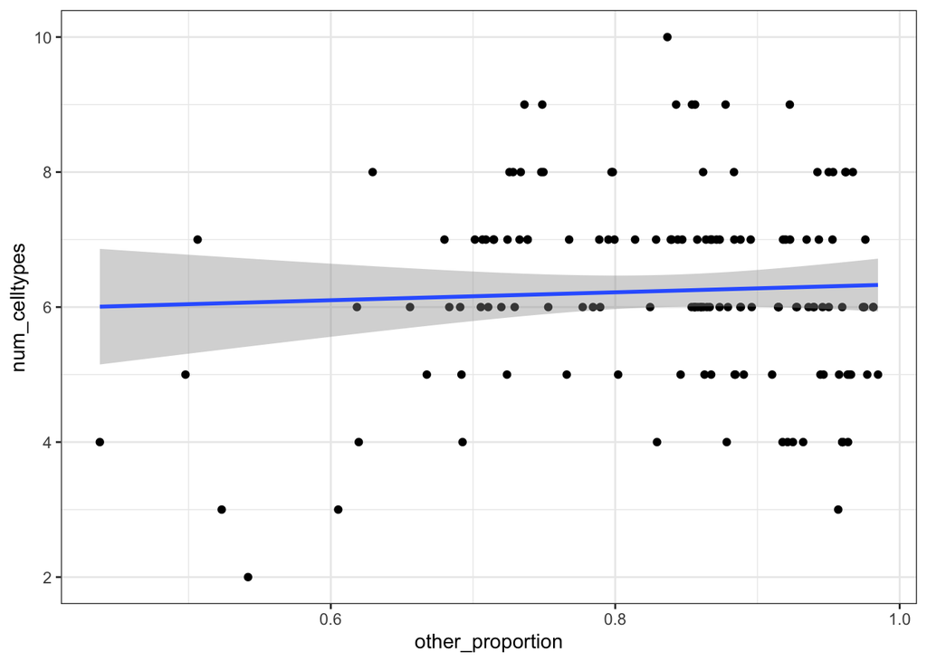

```r
ggplot(other_prop_df) +
  aes(x = other_proportion, y = num_celltypes) +
  geom_point() +
  geom_smooth(method = "lm")
```

Indeed there is no relationship, which is what we hoped!

## Conclusions

Although not all cell types are represented in all samples, there still appears to be a fair amount of diversity in cell types estimated. Most samples have at least 6 or 7 (out of 10) cell types represented.

Samples have a fairly decent range of “tumor purities” as well. This appears related to the originating lab group rather than varying randomly across all samples, which is in line with expectations that lab protocol and diagnosis will have a strong influence.